# 6-2. One-Sample Wilcoxon Signed Rank Test (non-parametric)

### 1. What’s one-sample Wilcoxon signed rank test?

- The one-sample Wilcoxon signed rank test is a non-parametric alternative to one-sample t-test when the data cannot be assumed to be normally distributed.
- It’s used to determine whether the median of the sample is equal to a known standard value (i.e. theoretical value).
- *Note* that,
  - the data should be distributed symmetrically around the median.
  - In other words, there should be roughly the same number of values above and below the median.

### 2. Research questions and statistical hypotheses

- Typical research questions are:
  - whether the median (m) of the sample is **equal** to the theoretical value (m<sub>0</sub>)?
  - whether the median (m) of the sample is **less than** to the theoretical value (m<sub>0</sub>)?
  - whether the median (m) of the sample is **greater than** to the theoretical value(m<sub>0</sub>)?
- In statistics, we can define the corresponding null hypothesis(H<sub>0</sub>) as follow:
  - H<sub>0</sub> : m = m<sub>0</sub>
  - H<sub>0</sub> : m ≤ m<sub>0</sub>
  - H<sub>0</sub> : m ≥ m<sub>0</sub>
- The corresponding alternative hypotheses(H<sub>1</sub>) are as follow:
  - H<sub>1</sub> : m ≠ m<sub>0</sub> (different)
  - H<sub>1</sub> : m > m<sub>0</sub> (greater)
  - H<sub>1</sub> : m < m<sub>0</sub> (less)
- *Note* that:
  - H<sub>0</sub> are called `two-tailed` tests if equal or different
  - H<sub>1</sub> are called `one-tailed` tests if greater or less

### 3. Visualize your data and compute one-sample Wilcoxon test in R

- Install `{ggpubr}` package for data visualization:
  - You can draw R base graphs as described at this link: R base graphs.
  - Here, we’ll use the `{ggpubr}` package for an easy ggplot2-based data visualization

```r
# install.packages("ggpubr")
```

- R function to compute one-sample Wilcoxon test
  - To perform one-sample Wilcoxon-test, the R function `wilcox.test{stats}` can be used as follow:

```r
wilcox.test(x, mu = 0, alternative = "two.sided")
```

- - `x` : a numeric vector containing your data values
  - `mu` : the theoretical mean/median value. Default is 0 but you can change it.
  - `alternative` : the alternative hypothesis. Allowed value is one of `two.sided` (default), `greater` or `less`.
- Import your data into R
  - Here, we’ll use an example data set containing the weight of 10 mice.

> We want to know, if the median weight of the mice differs from 25g?

```r
set.seed(1234)

(
  my_data <- data.frame(
                name = paste0(rep("M_", 10), 1:10),
                weight = round(rnorm(10, 20, 2), 1)
              )
)
```

```
##    name weight
## 1   M_1   17.6
## 2   M_2   20.6
## 3   M_3   22.2
## 4   M_4   15.3
## 5   M_5   20.9
## 6   M_6   21.0
## 7   M_7   18.9
## 8   M_8   18.9
## 9   M_9   18.9
## 10 M_10   18.2
```

- Check your data

```r
# Print the random sampled 10 rows of the data
library(dplyr)
sample_n(tbl = my_data, size = 10, replace = FALSE)
```

```
##    name weight
## 1   M_8   18.9
## 2   M_4   15.3
## 3   M_9   18.9
## 4   M_5   20.9
## 5  M_10   18.2
## 6   M_3   22.2
## 7   M_6   21.0
## 8   M_7   18.9
## 9   M_1   17.6
## 10  M_2   20.6
```

```r
# Statistical summaries of weight
summary(my_data$weight)
```

```
##    Min. 1st Qu.  Median    Mean 3rd Qu.    Max.
##   15.30   18.38   18.90   19.25   20.82   22.20
```

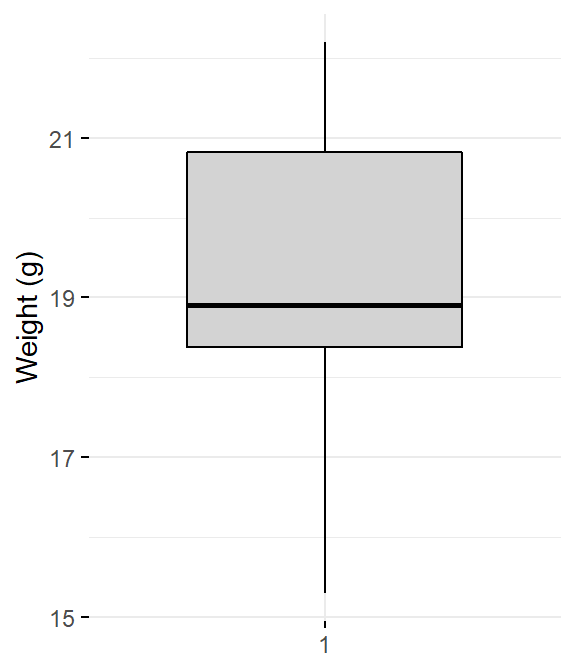

```r
library(ggpubr)

ggboxplot(my_data$weight, ylab = "Weight (g)", xlab = FALSE, ggtheme = theme_minimal(), fill='lightgray')
```

- Compute one-sample Wilcoxon test

> We want to know, if the average weight of the mice differs from 25g (two-tailed test)?

```r
# One-sample wilcoxon test
( res <- wilcox.test(my_data$weight, mu = 25) )
```

```
##
##  Wilcoxon signed rank test with continuity correction
##
## data:  my_data$weight
## V = 0, p-value = 0.005793
## alternative hypothesis: true location is not equal to 25
```

```r
# print only the p-value
res$p.value
```

```
## [1] 0.005793045
```

- The p-value of the test is 0.005793, which is less than the significance level alpha = 0.05.  
  We can reject the null hypothesis and conclude that the average weight of the mice is  
  significantly different from 25g with a p-value = 0.005793.
- Note that:
  - if you want to test whether the median weight of mice is less than 25g (one-tailed test), type this :

```r
wilcox.test(my_data$weight, mu = 25, alternative = "less")
```

```
##
##  Wilcoxon signed rank test with continuity correction
##
## data:  my_data$weight
## V = 0, p-value = 0.002897
## alternative hypothesis: true location is less than 25
```

- - Or, if you want to test whether the median weight of mice is greater than 25g (one-tailed test), type this :

```r
wilcox.test(my_data$weight, mu = 25, alternative = "greater")
```

```
##
##  Wilcoxon signed rank test with continuity correction
##
## data:  my_data$weight
## V = 0, p-value = 0.9979
## alternative hypothesis: true location is greater than 25
```